# Assessing the relationship of Nitrogen and Posphorus in freshwater rivers under varied flow conditions

# Introduction

In terrestrial and aquatic ecosystems, Nitrogen (N) and Pohsphorus (P) are usually the limiting factors on biotic growth (Marklein et al. 2011, CCME 2004 ). Increased P loading in waters can have negative effects on aquatic ecosystems and biota. The mechanism leading to these impacts is often increased algal growth due to higher P availability, which can cause eutrofication and hypoxia (CCME, 2004). Although this process is more common in polluted lakes, ponds, and wetlands, it can occur in rivers. Increased N loading can also have negative effects on riverine environments. N and P are both highly mobile nutrients when in solution, so it is expected that they would to some extent both increase under high-flow conditions. Because of their detrimental effects on aquatic ecosystems, it is useful to know which flow conditions threaten water quality and aquatic biota.

There is long-established, nonlinear, positive relationship between N and P flux (Rabalais, 2002). In this report, I test the hypothesis that higher flow conditions (low, moderate, high) are significantly associated with higher P (ug/L) levels. This report also considers covariates Nitrogen (mg/l), Chloride (mg/l), sample location (along river or reach), and weather condition (rainy/clear) as potential predictors of P levels. Ultimately, the question this study aims to answer is the following: which of the above variables can best predict Phosphorus levels in the areas sampled?

The null hypothesis states that there is no significant relationship between sample location, flow condition, weather condition, chloride, or nitrogen and phosphorus levels. In other words, the null hypothesis states that random noise outperforms the above variables in predicting Phosphorus levels.

# Methods

## Data exploration

#### Initial inspection

- **Site.ID**, one location along the Wardsboro River (NH), and two locations on the West River (NH)
- **Chl**, total Chloride (mg/l)
- **Nitro**, total Nitrogen (mg/l)
- **Phosph**, total Phosphorus (μg/L)
- **Flow.Condition**, rate of flow at sample location during sampling (low, moderate, high)
- **Weather.Status**, whether it was raining (wet), and not (dry)

All continuous data are bounded above zero, but Phosphorus was measured in micrograms per liter and, Nitrogen and Chloride were measured in milligrams per liter. Nitrogen and Chloride were scaled for modeling, and added to the original data under the column names Chlz for scaled Chloride and Nitroz for scaled Nitrogen. The below plots show data in the original scales unless otherwise noted.

A histogram of P levels shows a strong right skew, indicating these data are likely not normally-distributed.

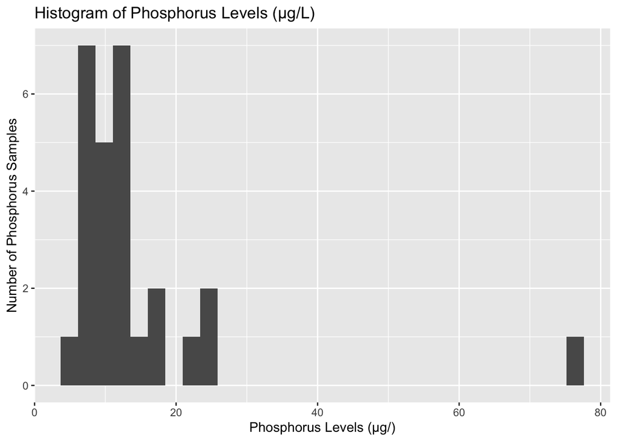

*Figure 1. A right-skewed histogram showing total Phosphorus levels (μg/L).*

The plot below shows one data point (77.4 (μg-P/L)) that seems to stand out as much higher than the rest. Initially, data exploration and model building continued with this data point, but it was eventually removed after testing Cooks Distance. This is covered in the section titled “Fit the Model”

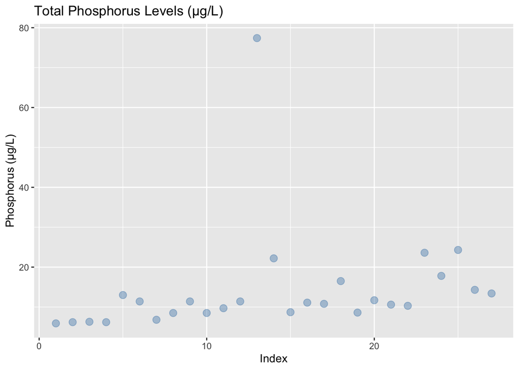

*Figure 2. A scatterplot of Phosphorus levels (μg/L) showing a data point (77.4) that was later removed as an outlier*

The conditional boxplots of Phosphorus levels by river flow condition show a much greater variation during low flow conditions.

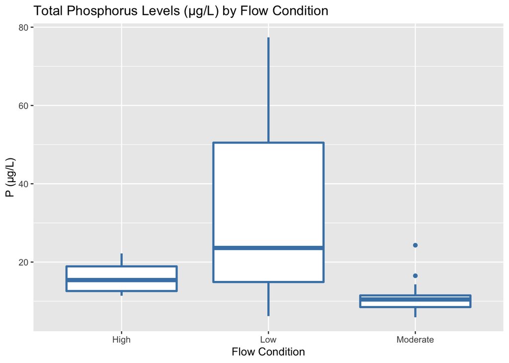

*Figure 3. A boxplot of Phosphorus (P) levels (μg/L) organized by Flow Condition (low, moderate, high), showing the relative variation among P levels across different flow conditions.*

After scaling continuous variables, a scatter plot of Nitrogen and Phosphorus shows what appears to be a positive relationship, with the exception of the probable outlier. Although informal and insufficient, this supports the prediction that Phosphorus and Nitrogen levels would fluctuate together.

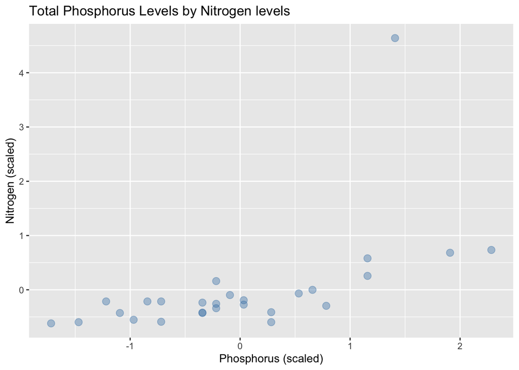

*Figure 4. A scatterplot of Phosphorus (scale) by Nitrogen (scaled) showing a potential slight positive association.*

## Hypotheses

#### Null hypothesis

As stated in the introduction, the null Hypothesis of this study is that there is no significant association between Site.ID, Chloride, Nitrogen, Flow Condition, or Weather Status, and P levels. The statistical formulation of the null hypothesis is as follows

Null hypothesis
$$y_i = 𝛽_{Phosph} + e_i$$
Where:
$$y_i$$
is the y intercept of response variable (P) of the model
$$𝛽_{Phosph}$$
is the mean P
$$e_i$$
is the error component of the model

Importantly, if and only if the above model receives a lower AIC score than any of the alternative hypotheses below, it will be considered the best model, and none of the independent variables above will be considered as significantly related to P levels.

### Alternative Hypothesis

The first alternative hypothesis is that N levels and high flow conditions are positively associated with P levels. Considering that there is a wide body of evidence supporting this hypothesis, a model representing this hypothesis is the focus of this study. All other hypotheses are tested as permutations of the variables in the global model, which is appears in the following section. For the sake of brevity, details on only the top three models are included in this report.

### Model Description

#### Model Structure

Linear Predictor
$$n_i =𝛽_{0} + 𝛽_{Flow}X_{P_i} + 𝛽_{Nitro_i}X_{P_i}$$

Link Function
$$μ = n = 1/𝛽_{0} + 𝛽_{Flow}X_{P_i} + 𝛽_{Nitro_i}X_{P_i}$$

Therefore
$$y_i = 𝛽_{0} + 𝛽_{Flow}X_{P_i} + 𝛽_{Nitro_i}X_{P_i} + e_i$$

Define the estimates:

$$𝛽_{0}$$
is mean P when Flow.Condition = High and Nitro = .11 (mg/L)

$$𝛽_{Flow}$$
is the slope coefficient showing the effect on P of a 1 unit change Flow.Condition

$$𝛽_{Nitro_i}$$
is the slope coefficient showing the effect on P of a 1 unit change in Nitro

## Model Fitting

```r
m0        <- glm(Phosph ~ 1,
                 data = noot,
                 family = gaussian(link = "inverse"))
m9.fn     <- glm(Phosph ~ Flow.Condition + Nitroz,
                 data = noot,
                 family = gaussian(link = "inverse"))
m18.n     <- glm(Phosph ~ Nitroz,
                 data = noot,
                 family = gaussian(link = "inverse"))
m7.full   <- glm(Phosph ~ Flow.Condition +
                   Site.ID + Chlz +
                   Nitroz + Weather.Status,
                 data = noot,
                 family = gaussian(link = "inverse"))
```

# Preliminary Results

#### Output evaluation (before outlier removal)

The Akaike information criterion (AIC), a metric commonly used to rank and/or compare the fit of regression models, was used for model selection. Models from a list were processed and organized into an AIC table using the R package “AICcmodavg” (Mazerolle, 2020). Before removing any outliers, model 6, which includes Flow.Condition, Site.ID, Chlz, and Nitroz as predictor variables had the lowest AIC score. The AIC table below shows the scores for each model.

|  | Modnames | K | AICc | Delta_AICc | ModelLik | AICcWt | LL | Cum.Wt |
| --- | --- | --- | --- | --- | --- | --- | --- | --- |
| 7 | m6.fscn | 8 | 142.1027 | 0.000000 | 1.000000e+00 | 9.002989e-01 | -59.05135 | 0.9002989 |
| 8 | m7.full | 9 | 146.5340 | 4.431263 | 1.090846e-01 | 9.820877e-02 | -58.97287 | 0.9985077 |
| 15 | m14.swn | 6 | 156.1964 | 14.093672 | 8.701577e-04 | 7.834020e-04 | -69.99819 | 0.9992911 |
| 6 | m5.fsc | 7 | 157.6179 | 15.515208 | 4.274796e-04 | 3.848595e-04 | -68.86159 | 0.9996759 |
| 16 | m15.swnc | 7 | 157.9868 | 15.884119 | 3.554736e-04 | 3.200325e-04 | -69.04604 | 0.9999960 |
| 5 | m4.fs | 6 | 166.9312 | 24.828524 | 4.060266e-06 | 3.655453e-06 | -75.36562 | 0.9999996 |
| 9 | m8.fc | 5 | 171.9256 | 29.822890 | 3.342271e-07 | 3.009043e-07 | -79.53423 | 0.9999999 |
| 13 | m12.sn | 5 | 175.0988 | 32.996079 | 6.838999e-08 | 6.157144e-08 | -81.12082 | 1.0000000 |
| 18 | m17.wn | 5 | 184.7592 | 42.656543 | 5.460714e-10 | 4.916275e-10 | -85.95105 | 1.0000000 |
| 12 | m11.sc | 5 | 198.1786 | 56.075905 | 6.656898e-13 | 5.993198e-13 | -92.66073 | 1.0000000 |

[output cut: 9 more lines]

```
##                     GVIF Df GVIF^(1/(2*Df))
## Flow.Condition 19.820410  2        2.109979
## Site.ID        16.781686  2        2.023992
## Chlz           11.964296  1        3.458944
## Nitroz          2.092941  1        1.446700
```

I assessed Cooks Distance, using the R package “car” (Fox and Weisberg, 2019) Cooks Distance quantifies the distance of residuals from the estimated mean of the response variable given a paticular model. The residuals vs. leverage plot of m6.fscn shows data points crossing Cooks Distance, indicating poor model fit and that outliers may be present.

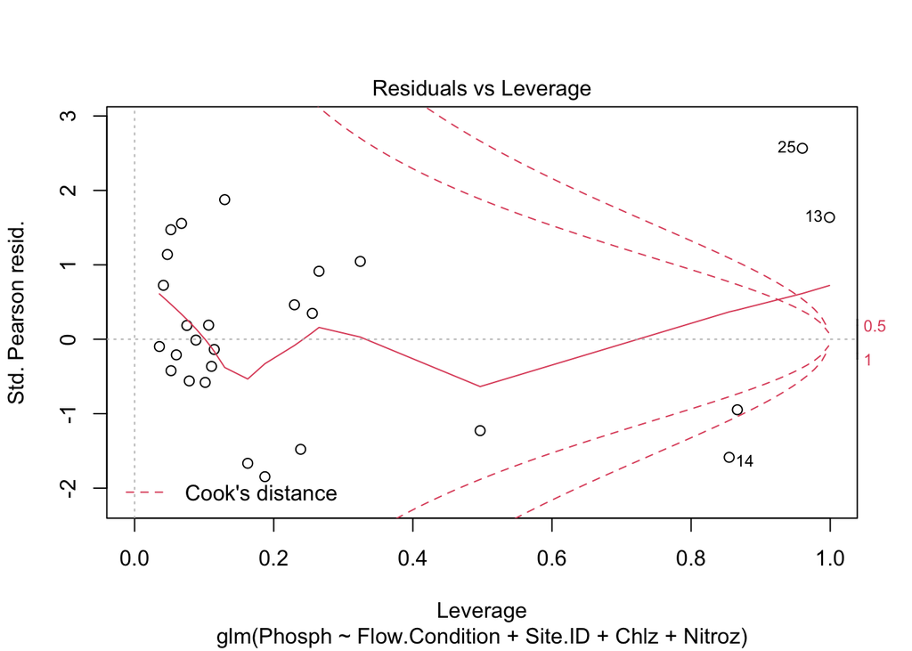

*Figure 5. The residuals vs. leverage plot showing data points beyond Cooks Distance, suggesting the prescence of outliers*

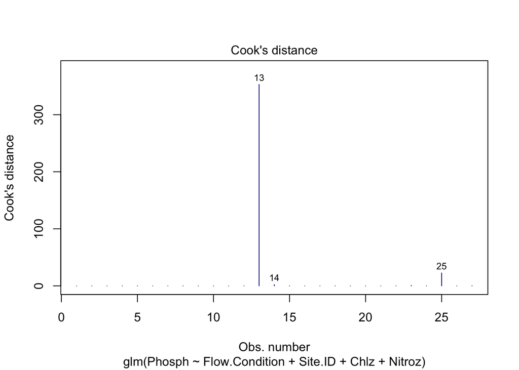

*Figure 6. A bar graph showing Cooks Distance for each observation*

Summary statistics of Cooks Distance for m6.fscn (the model that includes Flow.Condition, Site.ID, Chlz, and Nitro as predictor variables) are presented below. Visual inspection of the Cooks Distance plot and low first quartile, median, and third quartile values indicate overall low dispersion, with the exception of one outlier.

```
##     Min.  1st Qu.   Median     Mean  3rd Qu.     Max.
##   0.0000   0.0019   0.0092  14.0479   0.0875 353.0282
```

# Results

#### Evaluating Output: Model Selection using AIC

**AIC Table**

|  | Modnames | K | AICc | Delta_AICc | ModelLik | AICcWt | LL | Cum.Wt |
| --- | --- | --- | --- | --- | --- | --- | --- | --- |
| 10 | m9.fn | 5 | 131.6694 | 0.000000 | 1.000000e+00 | 5.218580e-01 | -59.33470 | 0.5218580 |
| 19 | m18.n | 3 | 133.8165 | 2.147069 | 3.417982e-01 | 1.783701e-01 | -63.36278 | 0.7002281 |
| 13 | m12.sn | 5 | 134.5523 | 2.882899 | 2.365845e-01 | 1.234635e-01 | -60.77615 | 0.8236917 |
| 7 | m6.fscn | 8 | 135.0422 | 3.372841 | 1.851812e-01 | 9.663828e-02 | -55.28582 | 0.9203299 |
| 18 | m17.wn | 5 | 137.2491 | 5.579671 | 6.143132e-02 | 3.205843e-02 | -62.12453 | 0.9523884 |
| 15 | m14.swn | 6 | 137.4178 | 5.748383 | 5.646176e-02 | 2.946502e-02 | -60.49836 | 0.9818534 |
| 8 | m7.full | 9 | 138.9518 | 7.282426 | 2.622052e-02 | 1.368339e-02 | -54.85091 | 0.9955368 |
| 16 | m15.swnc | 7 | 141.2090 | 9.539562 | 8.482239e-03 | 4.426524e-03 | -60.49337 | 0.9999633 |
| 5 | m4.fs | 6 | 152.6601 | 20.990716 | 2.766457e-05 | 1.443698e-05 | -68.11953 | 0.9999777 |
| 6 | m5.fsc | 7 | 152.7193 | 21.049893 | 2.685800e-05 | 1.401606e-05 | -66.24853 | 0.9999917 |

[output cut: 9 more lines]

After outlier removal, the summary statistics of Cooks Distance for the model m9.fn show a maximum reduced by 335.754, down from the original 353.023 to the current maximum, 17.269

```
##      Min.   1st Qu.    Median      Mean   3rd Qu.      Max.
##  0.000000  0.002420  0.004485  0.761276  0.022025 17.269250
```

##### Model Validation using a Variance Inflation Factor

I used a variance inflation factor again to evaluate the relative power of predictor variables in explaining P variability. According to the VIF output for the top model, m9.fn, GVIF values were 1.11 for Flow.Condition and Nitroz. Because these values are <2, the variables will be kept as predictors. These low VIF values combined with a lower Cooks Distance indicate that this model likely has adequate fit.

```
##                    GVIF Df GVIF^(1/(2*Df))
## Flow.Condition 1.111417  2        1.026761
## Nitroz         1.111417  1        1.054237
```

VIF values for the third best model (Delta AIC < 3 compared to top model) were 2.07 for both Site.ID and Nitro, indicating poorer model fit than the top model. At this point, m9.fn was selected as the best model, re-assigned to a variable called “mbest”, used in predictions, and interpreted.

```
##             GVIF Df GVIF^(1/(2*Df))
## Site.ID 2.073446  2        1.199978
## Nitroz  2.073446  1        1.439946
```

#### Interpreting results

Summary statistics for the top model, m9.fn, are shown below.

```
##
## Call:
## glm(formula = Phosph ~ Flow.Condition + Nitroz, family = gaussian(link = "inverse"),
##     data = noot)
##
## Deviance Residuals:
##     Min       1Q   Median       3Q      Max
## -5.6261  -1.4623   0.1276   1.3781   6.5314
##
## Coefficients:
##                         Estimate Std. Error t value Pr(>|t|)
## (Intercept)             0.077322   0.005063  15.272 3.42e-13 ***
## Flow.ConditionLow       0.014022   0.006981   2.008  0.05702 .
## Flow.ConditionModerate  0.017766   0.005568   3.191  0.00422 **
## Nitroz                 -0.024005   0.002745  -8.746 1.30e-08 ***
## ---
## Signif. codes:  0 '***' 0.001 '**' 0.01 '*' 0.05 '.' 0.1 ' ' 1
##
## (Dispersion parameter for gaussian family taken to be 6.641916)
##
##     Null deviance: 676.26  on 25  degrees of freedom
## Residual deviance: 146.12  on 22  degrees of freedom
## AIC: 128.67
##
## Number of Fisher Scoring iterations: 6
```

Because nitrogen was scaled before modeling, I back-transformed the Nitrogen estimate of -0.024005 for interpretation. The resulting estimate was 0.2411993.

```r
(-0.024005*sd.nitro)+mean.nitro
```

```
## [1] 0.2411993
```

#### Predictions

The regression plot was created using the predict function from the R package “stats”. Predictions were created for the range of values of Nitrogen, which was back transformed for plot-labeling. The prediction plot shows a positive relationship between increased N and the response variable, P. Even though Flow.ConditionLow did not have a significant relationship with P levels, this plot indicates that on average, higher flow conditions ehibit greater P levels than moderate flow conditions.

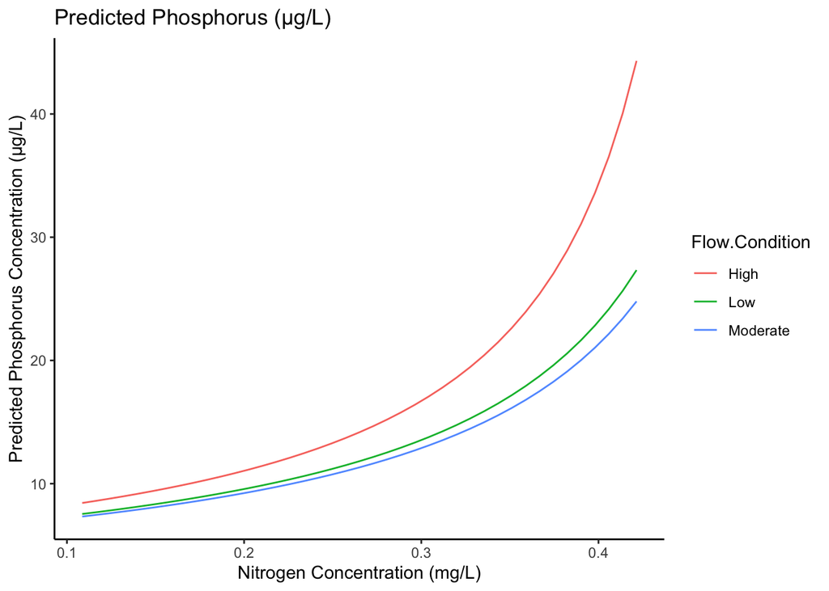

*Figure 7. Regression plot for predicted N and P under 3 flow rate scenarios*

Predictive model validation (for m9.fn) was completed using the R package, “DHARMa” (Hartig, 2022). The QQ plot of residuals in the DHARMa residuals plot below (left) shows moderate dispersion of residuals, deviation is not significant, and the Kolmogorov Smirnov Test indicates that the model fits well.

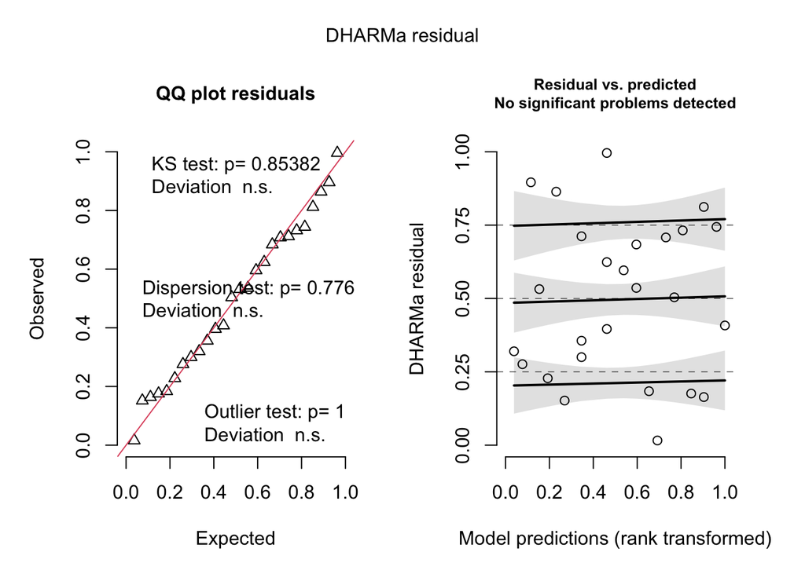

*Figure 8. DHARMa residuals plot for predictive model (m9.fn) showing observed and predicted residuals*

# Discussion

#### References

W. N. Venables and B. D. Ripley, Modern Applied Statistics with S 4th Edition, Springer, New York, 2002, ISBN 0-387-95457-0, https://www.stats.ox.ac.uk/pub/MASS4/

R Core Team, R: A Language and Environment for Statistical Computing, R Foundation for Statistical Computing, Vienna, Austria, 2021, https://www.R-project.org/

J Fox, S. Weisberg, An {R} Companion to Applied Regression 3rd edition, 2019, Sage, Thousand Oaks, CA, https://socialsciences.mcmaster.ca/jfox/Books/Companion/

M. J. Mazerolle, AICcmodavg: Model selection and multimodel inference based on (Q)AIC(c), 2020, R package version 2.3-1, https://cran.r-project.org/package=AICcmodavg

F. Hartig, DHARMa: Residual Diagnostics for Hierarchical (Multi-Level / Mixed) Regression Models, 2022, R package version 0.4.5, https://CRAN.R-project.org/package=DHARMa

Marklein, A. R., & Houlton, B. Z. (2011). Nitrogen inputs accelerate phosphorus cycling rates across a wide variety of terrestrial ecosystems. New Phytologist, 193(3), 696–704. https://doi.org/10.1111/j.1469-8137.2011.03967.x

Rabalais, Nancy N. “Nitrogen in Aquatic Ecosystems.” Ambio, vol. 31, no. 2, 2002, pp. 102–12, http://www.jstor.org/stable/4315222. Accessed 5 May 2022.

Canadian Council of Ministers of the Environment. 2004. Canadian water quality guidelines for the protection of aquatic life: Phosphorus: Canadian Guidance Framework for the Management of Freshwater Systems. In: Canadian environmental quality guidelines, 2004, Canadian Council of Ministers of the Environment, Winnipeg.